# Test crop PNA Illumina Run Dec2022

Briana K. Whitaker

2025-08-29

- Run using R version 4.4.1 (2024-06-14 ucrt).

# Objective

This document reports on results from the Illumina Nano Run in Dec 2022, on 40 samples. 1 primer pair only. 3 wheat head, 3 barley head, and 3 corn leaf samples times four PNA treatment levels Plus 2 corn debris samples as positive controls [no plant amplification in previous trials], and two PCR negative controls.

# Load Packages, set path to data

# Summarize & Remove Plant Reads

### Run hits from DECIPHER with low confidence at Kingdom level on ncbi browser

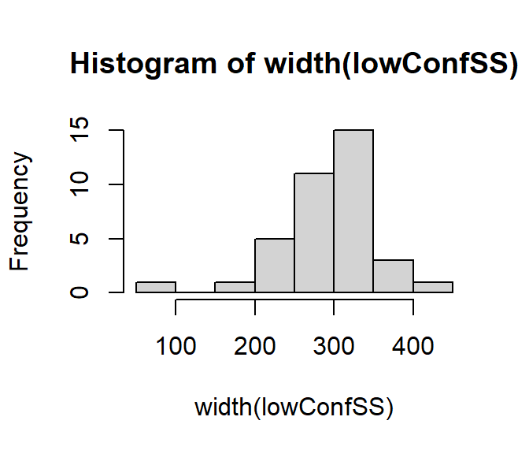

- ASVs that are low confidence from decipher output are generally longer than average for regular dataset ~50bp

```r
# ##write.csv(lowConfASVs, "./data/cropPNA_lowConfASVs.csv") #manually edited with blast-nr results
lowConf.ncbi <- read.csv("./data/cropPNA_lowConfASVs.csv", row.names = 1, stringsAsFactors = TRUE)

# table(lowConf.ncbi$Problematic)      # 16 problematic overall
# table(lowConf.ncbi$NCBI.Blast.Group) # 10 plant (leaving 6 as chimera seqs)
# table(lowConf.ncbi$NCBI.Blast.ID)    #3 Hordeum, 6 Triticum, 1 Hord/Trit chimera
```

- Overall 16 residual ASVs that are likely plant or chimera. Rest are Fungi, just weren’t determined from DECIPHER matches.
- 3 ASVs were Hordeum, while 6 were Triticum, and 1 was a Triticum-Hordeum chimera of sorts. In addition, 6 ASVs were likely chimeras

### subset phyloseq obj

```
## phyloseq-class experiment-level object
## otu_table()   OTU Table:         [ 264 taxa and 39 samples ]
## sample_data() Sample Data:       [ 39 samples by 25 sample variables ]
## tax_table()   Taxonomy Table:    [ 280 taxa by 7 taxonomic ranks ]
## refseq()      DNAStringSet:      [ 264 reference sequences ]
```

```r
sum(ps_fungi@otu_table['PCRneg-1',])
```

```
## [1] 243
```

```r
#sum(ps@otu_table['PCRneg-1',])
```

- Note, 243 reads in PCRneg1 sample (no reads passed filter for PCRneg2)
- None of the reads in the PCRneg1 are plant-origin.

### Plots of sequencing and plant contamination

##### Proportion of sample that is plant reads

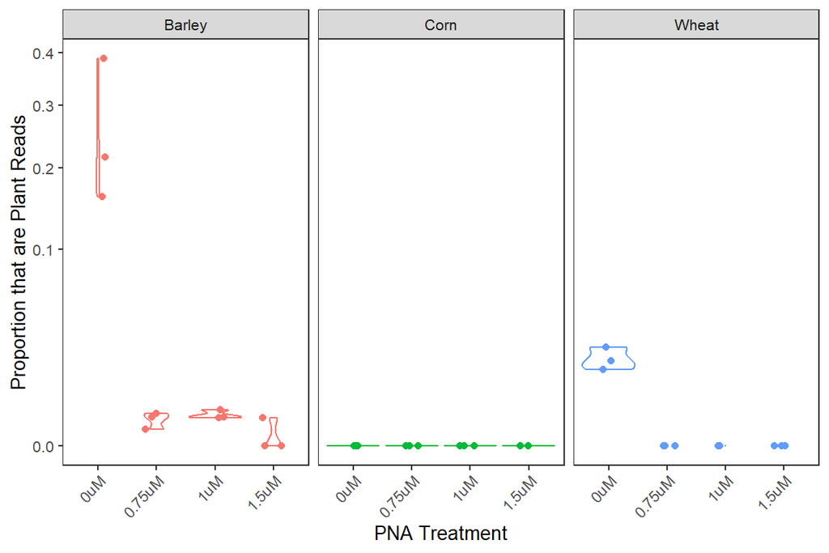

##### Raw Sequencing depth for sample after DADA2, prior plant removal

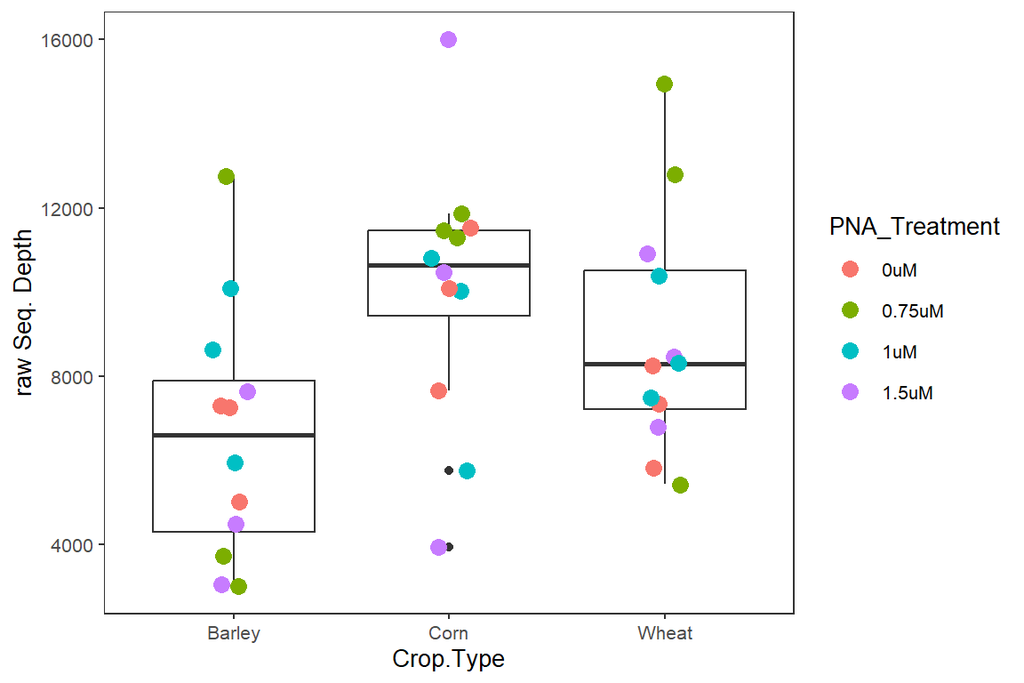

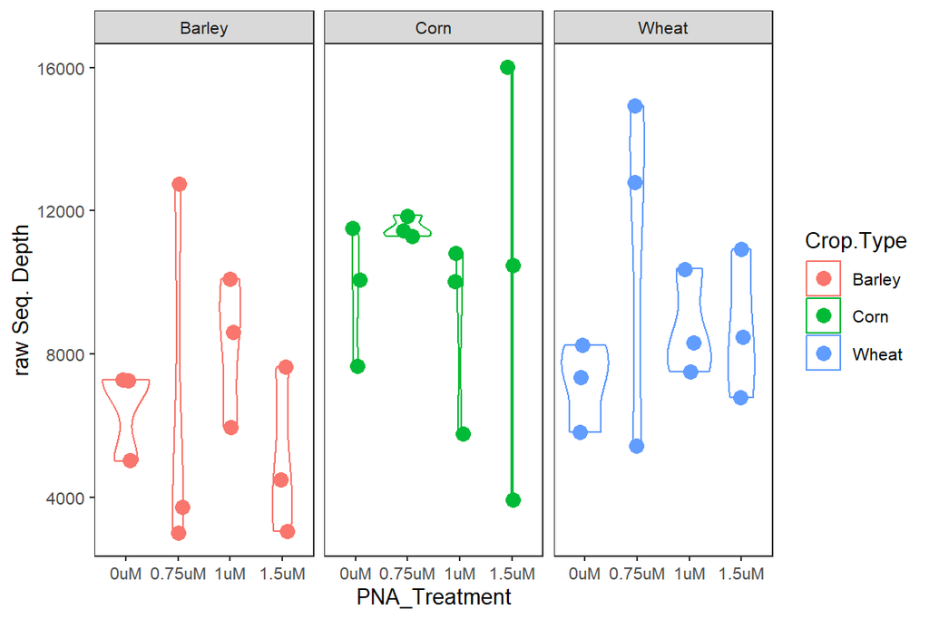

##### Sequencing depth for sample after plant removal

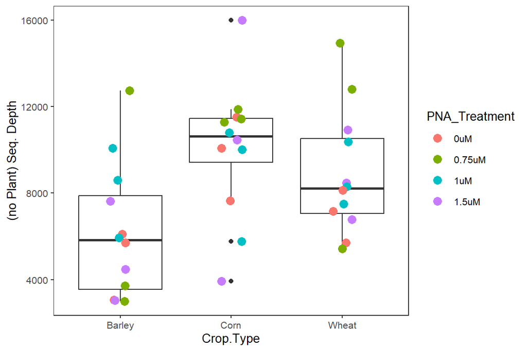

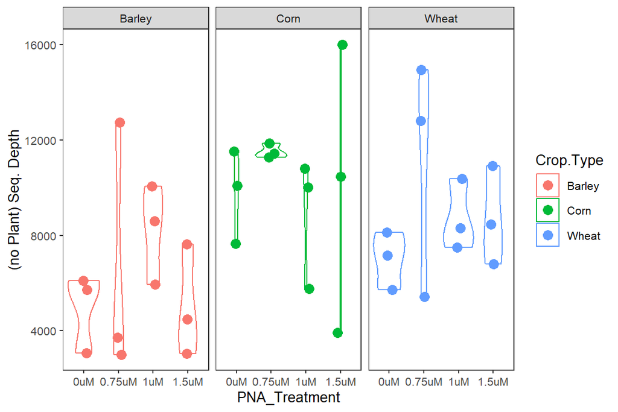

- biggest effect from crop type,

### Run Models

```
## Anova Table (Type II tests)
##
## Response: propPlant
##                           Sum Sq Df F value    Pr(>F)
## Crop.Type               0.031413  2  13.310  0.000129 ***
## PNA_Treatment           0.055793  3  15.760 7.101e-06 ***
## Crop.Type:PNA_Treatment 0.089260  6  12.607 2.100e-06 ***
## Residuals               0.028322 24
## ---
## Signif. codes:  0 '***' 0.001 '**' 0.01 '*' 0.05 '.' 0.1 ' ' 1
```

```
## Analysis of Deviance Table (Type II tests)
##
## Response: I(propPlant + 0.01)
##                         Df   Chisq Pr(>Chisq)
## Crop.Type                2 113.784  < 2.2e-16 ***
## PNA_Treatment            3 203.535  < 2.2e-16 ***
## Crop.Type:PNA_Treatment  6  84.695  3.818e-16 ***
## ---
## Signif. codes:  0 '***' 0.001 '**' 0.01 '*' 0.05 '.' 0.1 ' ' 1
```

```
## Analysis of Deviance Table (Type II tests)
##
## Response: propPlant
##                    Df  Chisq Pr(>Chisq)
## Crop.Type           2 33.859  4.443e-08 ***
## PNA_Treatment_cont  1 60.121  8.918e-15 ***
## ---
## Signif. codes:  0 '***' 0.001 '**' 0.01 '*' 0.05 '.' 0.1 ' ' 1
```

```
## Analysis of Deviance Table (Type II tests)
##
## Response: I(propPlant + 0.01)
##                              Df   Chisq Pr(>Chisq)
## Crop.Type                     2  71.007   3.81e-16 ***
## PNA_Treatment_cont            1 108.448  < 2.2e-16 ***
## Crop.Type:PNA_Treatment_cont  2  80.893  < 2.2e-16 ***
## ---
## Signif. codes:  0 '***' 0.001 '**' 0.01 '*' 0.05 '.' 0.1 ' ' 1
```

```
## Analysis of Deviance Table (Type II tests)
##
## Response: propPlant
##                         LR Chisq Df Pr(>Chisq)
## Crop.Type                 237.36  2     <2e-16 ***
## PNA_Treatment             352.30  3     <2e-16 ***
## Crop.Type:PNA_Treatment     0.26  6     0.9997
## ---
## Signif. codes:  0 '***' 0.001 '**' 0.01 '*' 0.05 '.' 0.1 ' ' 1
```

```r
## Bayesion ZOIB (zero inflated beta regression)
bf.mod <- bf(propPlant ~ Crop.Type*PNA_Treatment_cont,
     zi ~ Crop.Type) #phi ~ Crop.Type*PNA_Treatment_cont)
get_prior(
  bf.mod,
  data = test,
  family = zero_inflated_beta()
)
```

```
##                 prior     class                              coef group resp
##                (flat)         b
##                (flat)         b                     Crop.TypeCorn
##                (flat)         b  Crop.TypeCorn:PNA_Treatment_cont
##                (flat)         b                    Crop.TypeWheat
##                (flat)         b Crop.TypeWheat:PNA_Treatment_cont
##                (flat)         b                PNA_Treatment_cont
##  student_t(3, 0, 2.5) Intercept
##     gamma(0.01, 0.01)       phi
##                (flat)         b
##                (flat)         b                     Crop.TypeCorn
##                (flat)         b                    Crop.TypeWheat
##        logistic(0, 1) Intercept
##  dpar nlpar lb ub       source
##                        default
##                   (vectorized)
##                   (vectorized)
##                   (vectorized)
##                   (vectorized)
##                   (vectorized)
##                        default
##              0         default
##    zi                  default
##    zi             (vectorized)
##    zi             (vectorized)
##    zi                  default
```

```r
# don't want all the 'flat' priors
my.priors <- c(set_prior("student_t(3, 0, 2.5)", class = "Intercept"),
                    #keep the default prior for the intercept
               set_prior("normal(0, 2)", class = "b"))
                    #but add priors for the b class
plant.mod9 <- brm(bf.mod,
  data = test,
  family = zero_inflated_beta(),
  init = 0,
  #chains = 4, iter = 20, warmup = 10,
  #cores = 4, seed = 217,
  chains = 4, iter = 2000, warmup = 1000,
  cores = 4, seed = 217,
  backend = "rstan",
  prior = my.priors,
  file = "./data/plant.mod9"
)
plant.mod9
```

```
##  Family: zero_inflated_beta
##   Links: mu = logit; phi = identity; zi = logit
## Formula: propPlant ~ Crop.Type * PNA_Treatment_cont
##          zi ~ Crop.Type
##    Data: test (Number of observations: 36)
##   Draws: 4 chains, each with iter = 2000; warmup = 1000; thin = 1;
##          total post-warmup draws = 4000
##
## Regression Coefficients:
##                                   Estimate Est.Error l-95% CI u-95% CI Rhat
## Intercept                            -1.35      0.36    -2.17    -0.75 1.00
## zi_Intercept                         -2.00      0.92    -4.05    -0.45 1.00
## Crop.TypeCorn                         0.61      2.00    -3.26     4.58 1.00
## Crop.TypeWheat                       -1.80      0.69    -3.03    -0.31 1.00
## PNA_Treatment_cont                   -2.87      0.83    -4.31    -1.14 1.00
## Crop.TypeCorn:PNA_Treatment_cont      0.46      2.04    -3.51     4.47 1.00
## Crop.TypeWheat:PNA_Treatment_cont     0.36      2.00    -3.61     4.21 1.00
## zi_Crop.TypeCorn                      8.45      3.62     3.57    17.55 1.00
## zi_Crop.TypeWheat                     3.11      1.15     1.06     5.54 1.00
##                                   Bulk_ESS Tail_ESS
## Intercept                             3301     2550
## zi_Intercept                          3879     2544
## Crop.TypeCorn                         2955     2810
## Crop.TypeWheat                        1825     1909
## PNA_Treatment_cont                    1372     2300
## Crop.TypeCorn:PNA_Treatment_cont      3471     2932
## Crop.TypeWheat:PNA_Treatment_cont     2993     2854
## zi_Crop.TypeCorn                      1446     1128
## zi_Crop.TypeWheat                     3612     2280
##
## Further Distributional Parameters:
##     Estimate Est.Error l-95% CI u-95% CI Rhat Bulk_ESS Tail_ESS
## phi    24.28     16.06     4.55    64.84 1.00     1420     2247
##
## Draws were sampled using sampling(NUTS). For each parameter, Bulk_ESS
## and Tail_ESS are effective sample size measures, and Rhat is the potential
## scale reduction factor on split chains (at convergence, Rhat = 1).
```

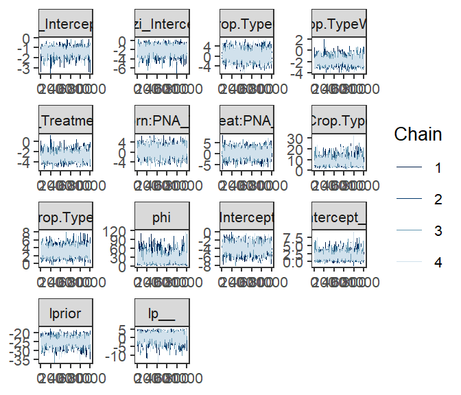

```r
## Model convergence
# inspect trace plots (for MCMC convergence)
mcmc_trace(plant.mod9)  #fuzzy caterpillae, all chains mixed and yielded the same estimate + approx credible interval
```

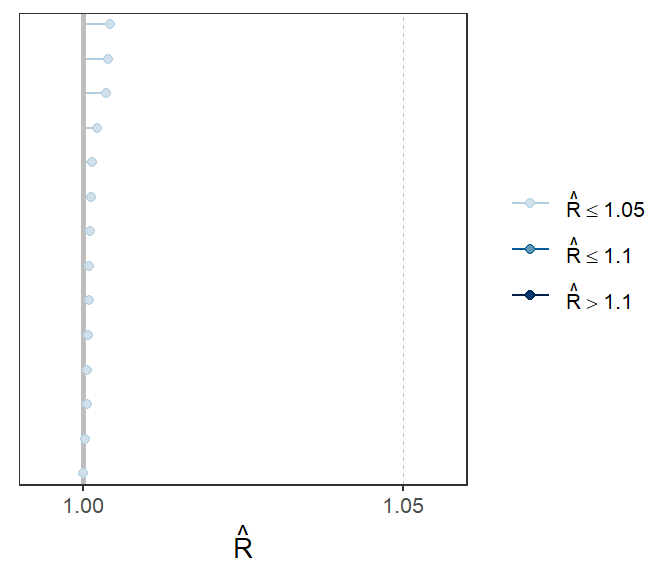

```r
# inspect Rhats
plant.mod9.rhats <- rhat(plant.mod9)
mcmc_rhat(plant.mod9.rhats)  # want rhats to be as close to 1 as possible
```

```r
# compares variance w/i chains to vairance b/w chains
# values below 1.01 are good, which all of these are < 1.005
table(plant.mod9.rhats<1.01)
```

```
##
## TRUE
##   14
```

```r
# also there were no warnings about the bulk or Tail effective sample size (ESS), which are all above at least 1000 in this model
# and no warnings about transitions exceeding the max. treedepth

# examine estimates
plogis(-1.35)
```

```
## [1] 0.2058704
```

```r
# 20% increase in proportion plant reads in barley
plogis(-1.35 + -1.80) - plogis(-1.35)
```

```
## [1] -0.1647791
```

```r
#16% decrease in proportion plant reads in wheat relative to barley
# note - corn B estimate includes 0 in CI, so probably most of the information for corn is contained in the zi parm
plogis(-1.35 + -2.87) - plogis(-1.35)
```

```
## [1] -0.1913846
```

```r
# 19% decrease in proportion plant reads with increase in PNA concentration of 1uM. Note - this is only true for default intercept which is barley, both the interaction terms with corn and wheat include 0 in the credible intervals

plogis(-2.00)
```

```
## [1] 0.1192029
```

```r
#12% 0s in barley (which is about accurate)
plogis(-2.00 + 8.45) - plogis(-2.00)
```

```
## [1] 0.879219
```

```r
#88% increase in 0s in corn relative to barley
plogis(-2.00 + 3.11) - plogis(-2.00)
```

```
## [1] 0.6329262
```

```r
#63% increase in 0s in corn relative to barley


# # try to include interaction
# bf.mod2 <- bf(propPlant ~ Crop.Type*PNA_Treatment_cont,
#               zi ~ Crop.Type*PNA_Treatment_cont) #phi ~ Crop.Type*PNA_Treatment_cont)
# plant.mod10 <- brm(bf.mod2,
#   data = test,
#   family = zero_inflated_beta(),
#   init = 0,
#   #chains = 4, iter = 20, warmup = 10,
#   #cores = 4, seed = 217,
#   chains = 4, iter = 2000, warmup = 1000,
#   cores = 4, seed = 217,
#   backend = "rstan",
#   prior = my.priors,
#   file = "./data/plant.mod10"
# )
# plant.mod10
# # lots of warnings about low ESS, large Rhats, and transitions exceeding max treedepth
# #mcmc_trace(plant.mod10) #looks really bad
# # poor model convergence
```

- Both crop type and PNA treatment have an effect on the proportion of plant reads contaminating a sample.
- Normal linear model implies: Barley 0uM worse than any other barley trt (L,M,H), and also barley 0uM worse than all corn and wheat trts (all 0,L,M,H). But, though the wheat 0uM looks higher, it is not statistically different from wheat PNA trts (L,M,H)
- Bayesian regression model largely supports this lm model interpretation

```r
raw.mod1 <- lm(postChimera ~ Crop.Type*PNA_Treatment, data = test)
car::Anova(raw.mod1, type = 2)  # only crop type has an effect on seq depth, not inclusion of the PNA
```

```
## Anova Table (Type II tests)
##
## Response: postChimera
##                            Sum Sq Df F value Pr(>F)
## Crop.Type                76218708  2  3.7488 0.0383 *
## PNA_Treatment            19842199  3  0.6506 0.5903
## Crop.Type:PNA_Treatment  29864969  6  0.4896 0.8096
## Residuals               243978850 24
## ---
## Signif. codes:  0 '***' 0.001 '**' 0.01 '*' 0.05 '.' 0.1 ' ' 1
```

```r
depth.mod1 <- lm(seqDepth_noPlant ~ Crop.Type*PNA_Treatment, data = test)
car::Anova(depth.mod1, type = 2)
```

```
## Anova Table (Type II tests)
##
## Response: seqDepth_noPlant
##                            Sum Sq Df F value  Pr(>F)
## Crop.Type                95573331  2  4.6686 0.01938 *
## PNA_Treatment            29203412  3  0.9510 0.43171
## Crop.Type:PNA_Treatment  27741878  6  0.4517 0.83658
## Residuals               245659615 24
## ---
## Signif. codes:  0 '***' 0.001 '**' 0.01 '*' 0.05 '.' 0.1 ' ' 1
```

```r
#depth.aov <- aov(seqDepth_noPlant ~ Crop.Type*PNA_Treatment, data = test)
#TukeyHSD(depth.aov, which = "Crop.Type")  #corn diff from barley, but not wheat, wheat not diff from barley
```

- However, only crop type has an effect on the total number of raw reads that pass through the DADA2 pipeline, and also the only significant effect on the total sequence depth after removal of plant reads.

# Examine Controls

```r
ps_cont <- subset_samples(ps_fungi, trtID == "PCRneg-1")
ps_cont <- filter_taxa(ps_cont, function(x) mean(x) > 0, TRUE)
otu_table(ps_cont)
```

```
## OTU Table:          [9 taxa and 1 samples]
##                      taxa are columns
##          ASV2 ASV3 ASV17 ASV18 ASV22 ASV25 ASV58 ASV77 ASV206
## PCRneg-1  122   37    17    22     2    14     9     8     12
```

```r
bad_taxa <- taxa_names(ps_cont)
```

- 9 ASVs in controls. More than usual.

```r
ps_fungi@tax_table[bad_taxa] # 14 reads
```

```
## Taxonomy Table:     [9 taxa by 7 taxonomic ranks]:
##        kingdom phylum          class
## ASV2   "Fungi" "Ascomycota"    "Dothideomycetes"
## ASV3   "Fungi" "Ascomycota"    "Dothideomycetes"
## ASV17  "Fungi" "Basidiomycota" "Tremellomycetes"
## ASV18  "Fungi" "Basidiomycota" "Cystobasidiomycetes"
## ASV22  "Fungi" "Basidiomycota" NA
## ASV25  NA      NA              NA
## ASV58  "Fungi" "Basidiomycota" "Microbotryomycetes"
## ASV77  "Fungi" "Ascomycota"    "Dothideomycetes"
## ASV206 "Fungi" "Basidiomycota" "Microbotryomycetes"
##        order                                    family
## ASV2   "Pleosporales"                           "Pleosporaceae"
## ASV3   "Capnodiales"                            "Cladosporiaceae"
## ASV17  "Tremellales"                            "Bulleribasidiaceae"
## ASV18  "Cystobasidiomycetes_ord_Incertae_sedis" "Symmetrosporaceae"
## ASV22  NA                                       NA
## ASV25  NA                                       NA
## ASV58  "Sporidiobolales"                        "Sporidiobolaceae"
## ASV77  "Pleosporales"                           "Pleosporaceae"
## ASV206 "Sporidiobolales"                        "Sporidiobolaceae"
##        genus            species
## ASV2   "Alternaria"     NA
## ASV3   "Cladosporium"   NA
## ASV17  "Hannaella"      NA
## ASV18  "Symmetrospora"  NA
## ASV22  NA               NA
## ASV25  NA               NA
## ASV58  "Sporobolomyces" NA
## ASV77  NA               NA
## ASV206 "Rhodotorula"    "Rhodotorula_mucilaginosa"
```

```r
# variable taxonomy
#sort(rowSums(ps_fungi@otu_table[,bad_taxa]), dec = TRUE)
## reads that appear in the negative, appear in every other sample run.
```

- Small problem with contamination in this run. Use SCRuB to decontaminate.

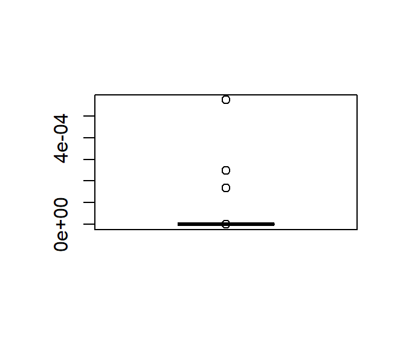

```r
meta <- (as(sample_data(ps_fungi), "data.frame"))
mat <- (as(otu_table(ps_fungi), "matrix"))

# format for SCRuB
meta$sample_well <- as.character(meta$Well)
meta$is_control <- ifelse(meta$trtID== "PCRneg-1", "TRUE", "FALSE")
meta$sample_type <- ifelse(meta$trtID== "PCRneg-1", "NegControl",
                           ifelse(meta$Crop.Type== "Debris", "Debris", "Phyllosphere"))
meta %>% arrange(trtID) %>% select(is_control, sample_type, sample_well) -> meta
mat %>% data.frame %>% mutate(ids = rownames(mat)) %>%
    arrange(ids) %>% select(-ids) %>% as.matrix -> mat
#identical(rownames(mat), rownames(meta)) #TRUE

# scr_out <- SCRuB(mat, meta, control_order = "NegControl" )  #with spatial info aka well info
# save(scr_out, file="./data/cropPNA_scrubOut.RData")
load("./data/cropPNA_scrubOut.RData")

# Estimated contamination level #read boxplot as contam proportion
(1 - scr_out$p) %>% boxplot()
```

```r
median(100-(scr_out$p*100))  #0%  (in percentages)
```

```
## [1] 0
```

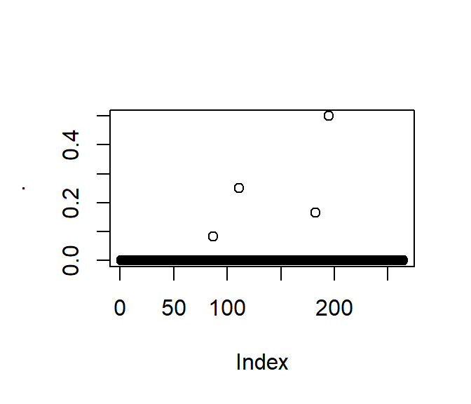

```r
# Estimated realtive abundance of the contamination community
scr_out$inner_iterations$`NegControl`$gamma %>% plot()  # 4 asvs w/ some higher contam
```

```r
### Estimate well-to-well leakage from PCR controls
scr_out$inner_iterations$`NegControl`$alpha[, ncol(scr_out$inner_iterations$`NegControl`$alpha)]
```

```
## [1] 0.04938272
```

```r
# 0.05% well-to-well leakage across plate

# final SbyS mat cleaned up
decon <- scr_out$decontaminated_samples %>% as.matrix()
dim(decon) # removes neg. control, 38 samples remain, 264 taxa (loss of 16 taxa)
```

```
## [1]  38 264
```

```r
#dim(SbyS)
```

# Diversity

- For the statistical models, I only compared the wheat head, barley head, and corn leaf samples, not the debris or negative control.

### H Diversity

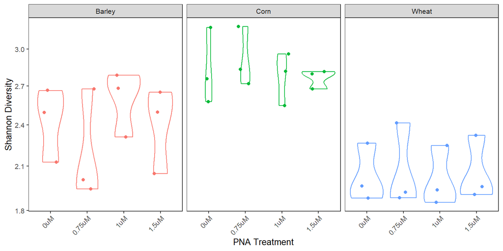

```r
# format for diversity
SbyE <- SbyE[order(SbyE$trtID),] %>% filter(trtID != "PCRneg-1")
#identical(rownames(SbyE), rownames(decon)) #must be TRUE
SbyE$Diversity <- diversity(decon, index = 'shannon')
SbyE2 <- SbyE %>% filter(Crop.Type != 'Debris')
SbyE2$PNA_Treatment <- factor(SbyE2$PNA_Treatment,
                              levels = c("0uM", "0.75uM", "1uM", "1.5uM"))

p2 <- ggplot(SbyE2, aes(x = PNA_Treatment, y = Diversity, color = Crop.Type)) +
  facet_grid(.~Crop.Type) +
  geom_violin() + geom_jitter(size = 1.5, width = 0.2) +
  guides(color = 'none') +
  scale_x_discrete("PNA Treatment") +
  scale_y_continuous("Shannon Diversity", trans = "sqrt") +
  theme(axis.text.x = element_text(angle = 45, hjust = 1))

#tiff("./figures/Fig3a_cropPNA.tiff", width=3.25, height=3.25, units="in", res=300)
p2
```

```r
#dev.off()

h.mod1 <- lm(Diversity ~ Crop.Type*PNA_Treatment, data = SbyE2)
#par(mfrow=c(2,2))
#plot(h.mod1)
car::Anova(h.mod1, type = 2)
```

```
## Anova Table (Type II tests)
##
## Response: Diversity
##                         Sum Sq Df F value    Pr(>F)
## Crop.Type               3.6195  2 26.1303 9.439e-07 ***
## PNA_Treatment           0.0206  3  0.0990    0.9598
## Crop.Type:PNA_Treatment 0.2532  6  0.6094    0.7204
## Residuals               1.6622 24
## ---
## Signif. codes:  0 '***' 0.001 '**' 0.01 '*' 0.05 '.' 0.1 ' ' 1
```

### Structure

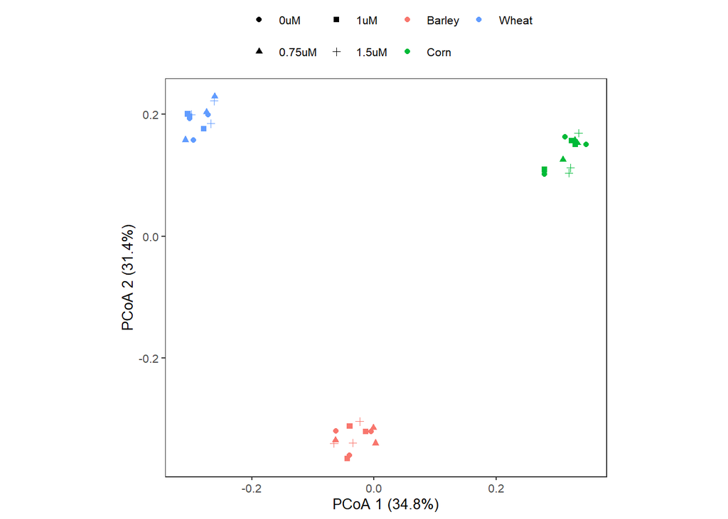

```r
SbyS2 <- decon[rownames(decon) %in% rownames(SbyE2),]
SbyS2 <- SbyS2[,colSums(SbyS2) >0]    #29 ASVs unique to debris
#dim(decon); dim(SbyS2)
SbyS2.hel <- decostand(SbyS2, method = 'hellinger')
dist <- vegdist(SbyS2.hel, method = 'bray')
pcoa <- cmdscale(dist, eig =TRUE)
expl_1 <- round(pcoa$eig[1] / sum(pcoa$eig), 3) * 100
expl_2 <- round(pcoa$eig[2] / sum(pcoa$eig), 3) * 100
expl_3 <- round(pcoa$eig[3] / sum(pcoa$eig), 3) * 100
scores <- as.data.frame(pcoa$points)
scores$ids <- rownames(scores)
pdat <- merge(scores, SbyE2, by.x="ids", by.y="trtID")
rownames(pdat) <- as.character(pdat$ids)

p3 <- ggplot() + coord_equal() +
    geom_point(data = pdat, aes(x = V1, y = V2,
          color = Crop.Type, shape = PNA_Treatment) , size = 1.5) +
    scale_x_continuous(paste("PCoA 1 (", expl_1, "%)", sep = "")) +
    scale_y_continuous(paste("PCoA 2 (", expl_2, "%)", sep = "")) +
  scale_color_discrete("") + scale_shape_discrete("") +
  guides(color = guide_legend(nrow = 2), shape = guide_legend(nrow = 2)) +
  theme(legend.position = 'top',
        legend.spacing.x = unit(0.0, "cm"),
        legend.margin = margin(0, 0, 0, 0, unit = "cm"))
#tiff("./figures/Fig3b_cropPNA.tiff", width=3.25, height=3.25, units="in", res=300)
p3
```

```r
#dev.off()

#test interaction
out <-adonis2(SbyS2.hel ~ Crop.Type*PNA_Treatment, data = SbyE2,
              method = 'bray', by = "margin")
out   #not sgnif
```

```
## Permutation test for adonis under reduced model
## Marginal effects of terms
## Permutation: free
## Number of permutations: 999
##
## adonis2(formula = SbyS2.hel ~ Crop.Type * PNA_Treatment, data = SbyE2, method = "bray", by = "margin")
##                         Df SumOfSqs      R2      F Pr(>F)
## Crop.Type:PNA_Treatment  6   0.0555 0.00869 0.1055      1
## Residual                24   2.1041 0.32949
## Total                   35   6.3858 1.00000
```

```r
# test main effects
out2 <-adonis2(SbyS2.hel ~ Crop.Type+PNA_Treatment, data = SbyE2,
             method = 'bray', by = "margin")
out2
```

```
## Permutation test for adonis under reduced model
## Marginal effects of terms
## Permutation: free
## Number of permutations: 999
##
## adonis2(formula = SbyS2.hel ~ Crop.Type + PNA_Treatment, data = SbyE2, method = "bray", by = "margin")
##               Df SumOfSqs      R2       F Pr(>F)
## Crop.Type      2   4.1971 0.65726 29.1527  0.001 ***
## PNA_Treatment  3   0.0291 0.00455  0.1346  1.000
## Residual      30   2.1596 0.33818
## Total         35   6.3858 1.00000
## ---
## Signif. codes:  0 '***' 0.001 '**' 0.01 '*' 0.05 '.' 0.1 ' ' 1
```

```r
# NOTE - vegan::adonis2 has changed versions/formulas since this script was first written; so model script has changed, but results are the same.
```

*Only crop type affects the community structure and shannon diversity, not PNA test (=good!)